# 6. 朴素贝叶斯

Natural Language Processing I

6. 朴素贝叶斯

WU Xiaokun 吴晓堃

xkun.wu [at] gmail

2022/04/01

# 文本分类任务

## 垃圾邮件

这是不是垃圾邮件？

```
你想不过你的日收入入过万呢!那请马上加入我们的游戏吧！www.zxxzg.com 公平公证！新手进来可领取首次登陆礼金。9lx怯
```

## 文本风格

谁写了下面这段文字？

```
看来有很多人说，王二不存在。这件事叫人困惑的原因就在这里。
大家都说存在的东西一定不存在，这是因为眼前的一切都是骗局。
大家都说不存在的东西一定存在，比如王二，假如他不存在，这个名字是从哪里来的？
```

> 写出《黄金时代》之前，我从未觉得自己写得好。–王小波

## 正负面评价

情感分类：酒店评价

- “前台态度非常好！早餐很丰富，房间很干净。”
- “结果大失所望，灯光昏暗，空间狭小，房间有霉味。”

注意：“情感分类”也可以是客观评价

```
该生使用深度学习的方法，实现了一个文本情感分类系统。很好的完成了任务书规定的工作量，除按时完成外文翻译外，并能阅读一些自选资料，设计合理，有较强的实践动手能力，成果具有实际应用意义，论文结构合理，论述层次清晰，论文符合规范化要求。在答辩过程中能够对系统进行分析并得出合理正确的结论。
```

```
该生使用Unity3D框架完成了一个小游戏。在答辩过程中对问题不能正确回答。
```

## 学科分类

BERT: Pre-training of Deep Bidirectional Transformers for Language Understanding

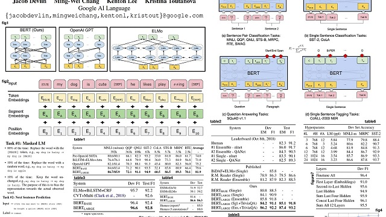

学科分类与代码

| 520 | 计算机科学技术 |
| --- | --- |
| 52020 | 人工智能 |
| 5202020 | 自然语言处理 |

## 文本分类定义

输入

- 文档：$d$；固定的类别集合：$C = \{c_1, c_2, .., c_m\}$

输出

- 预测类别：$c \in C$

## 方法：预定义规则

领域专家根据**特征**集合给出的**规则**

- 垃圾邮件特征：黑名单 `OR` (“大礼包” `AND` “注册”)
- 例如：数模型，分支判定

精度可以很高

- 如果“专家”确实对领域非常熟悉
- 人工经验：构建及维护成本高

## 方法：监督学习

输入

- 文档：$d$；固定的类别集合：$C = \{c_1, c_2, .., c_m\}$
- **标注好的训练集**：$(d_1,c_1),..,(d_n,c_n)$

输出

- **分类器**：$\gamma:d \rightarrow c$

回顾：**机器学习范式**

- 自动化（经验）规则提取：替代特征工程
- 能够预测新文档

# 朴素 Bayes 分类器

## 朴素贝叶斯

**朴素贝叶斯 naïve （天真幼稚的） Bayes**

- 模型简单：假设相对朴素
- 理论依据：Bayes 规则

数据表示也很简单

- **词袋 bag-of-words**

## 词袋

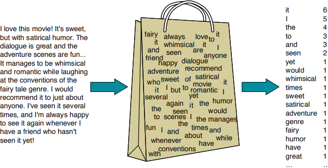

- **无序**的词汇集合
- 基本统计信息：**频率**

## Bayes 规则

[Bayes 1763] **Bayes 推断 inference**

- 全概率公式

$$\begin{aligned}
P(AB) = P(A|B)P(B) &= P(B|A)P(A)\\
\end{aligned}$$

[figure not shown]

- Bayes 规则：即条件概率公式

$$\begin{aligned}
P(A|B) &= \frac{P(B|A)P(A)}{P(B)}\\
\end{aligned}$$

- [Mosteller 1964] 应用于文本分类问题

## 文档分类估计

给定文档$d$，**估计**其类别$c$作为输出；但优化**目标**是概率

$$\begin{aligned}
\hat{c} &= \argmax_{c \in C} P(c|d)\\
&= \argmax_{c \in C} \frac{P(d|c)P(c)}{P(d)}
\end{aligned}$$

注意：$P(d)$不随文档类别$c$变化，即**没有参数依赖关系**

- $P(d)$仅取决于文档的分布；计算不同$c$时$d$不变

$$\begin{aligned}
\hat{c} &= \argmax_{c \in C} P(d|c)P(c)
\end{aligned}$$

## 最大后验概率

**最大后验 Maximum A Posterior (MAP) 概率**

- A posteriori, Latin for “from the latter”

$$\begin{aligned}
\hat{c}_{MAP} &= \argmax_{c \in C} \overbrace{P(d|c)}^{\text{likelihood}} \overbrace{P(c)}^{\text{prior}}
\end{aligned}$$

- **先验 prior 概率**：对被估计量的经验假设，与输出一致
  - 通常是因为还没有观测到（足够多的）数据
- **似然 likelihood**：“可能性”的一种较文艺的说法
  - 并非“概率”：给定样本$d$，参数（实数）$c$（相对其他参数选择）的可能性

## 解决似然的理论问题

似然是一种**经验（而非客观）规律**的描述，无法识别“偶发事件”

$$\begin{aligned}
P(w_n|w_{n-1}) = \frac{\Gamma(w_{n-1}w_n)}{\sum_w \Gamma(w_{n-1}w)} &= \frac{\Gamma(w_{n-1}w_n)}{\Gamma(w_{n-1})}\\
P(下雨|吴老师来上课) &= \frac{\Gamma(下雨, 吴老师来上课)}{\Gamma(吴老师来上课)}\\
&= \frac{9}{12} = .75
\end{aligned}$$

先验概率的重要性：先验是对**客观规律的经验总结**

$$\begin{aligned}
\hat{P}(下雨) &\propto \overbrace{P(吴老师来上课|下雨)}^{\text{likelihood}} \overbrace{P(下雨)}^{\text{prior}}
\end{aligned}$$

## MAP 概率举例

例如吸烟导致肺癌的概率

$$\begin{aligned}
\hat{c}_{MAP} &= \argmax_{c \in C} \overbrace{P(d|c)}^{\text{likelihood}} \overbrace{P(c)}^{\text{prior}}
\end{aligned}$$

- 没拿到检测报告前，只能凭经验给出一个相对普遍的关联性
- 检测报告会**对先验概率做出修正**，最终导致后验概率的改变

## 生成模型

朴素 Bayes 通常被认为是一种**生成模型 generative model**

- 模型在公式（右侧）上隐含着生成数据的逻辑假设

$$\begin{aligned}
\hat{c}_{MAP} &= \argmax_{c \in C} P(d|c)P(c)
\end{aligned}$$

1. 首先从$P(c)$中采样出类别
2. 然后从$P(d|c)$中采样出文本

但直接生成文档过于复杂：文档空间几乎是无限维

- 转而生成文档的**有限特征描述**

## 文档特征

文档可以看成由一系列**特征 feature** 构成

$$\begin{aligned}
\hat{c}_{MAP} &= \argmax_{c \in C} \overbrace{P(f_1,f_2,..,f_n|c)}^{\text{likelihood}} \overbrace{P(c)}^{\text{prior}}
\end{aligned}$$

- 特征可以理解为数据中**有效信息的压缩形式**，及其（几何意义上的）变换
  - 最简单的特征就是（字/词：频率）的向量表示

问题：计算量仍然过大

- 特征集合所有可能的组合：$O(|X|^n|C|)$

## 两个简化假设

**词袋表示**假设：特征（比如词）只考虑类别，不考虑序列位置关系

**朴素 Bayes**假设：特征之间条件独立，不考虑条件（参数）的相关性

$$P(f_1, f_2, .., f_n|c) = P(f_1|c) \cdot P(f_2|c) \cdot .. \cdot P(f_n|c)$$

朴素 Bayes **分类器**

$$\begin{aligned}
\hat{c}_{NB} &= P(f_1, f_2, .., f_n|c) P(c)\\
&= \argmax_{c \in C} P(c) \prod_{f \in F} P(f|c)\\
\end{aligned}$$

## NB分类器应用：文本

文本由字符串构成：$d = w_1 w_2 .. w_n$

- **遍历**文本中的每个词

$$\hat{c}_{NB} = \argmax_{c \in C} P(c) \prod_{i} P(w_i|c)\\$$

问题：大量概率值相乘可能导致**浮点数下溢**

- 概率取值范围：$[0,1]$
- 词数很多的文本非常常见

## 对数空间计算

$$\begin{aligned}
\hat{c}_{NB} &= \argmax_{c \in C} P(c) \prod_{i} P(w_i|c)\\
&= \argmax_{c \in C} \log \left(P(c) \prod_{i} P(w_i|c) \right)\\
&= \argmax_{c \in C} \log P(c) + \sum_{i} \log P(w_i|c)\\
\end{aligned}$$

- 取对数不改变最大值：单调增函数**保持序关系**
- NB分类器是**线性模型**：（对数空间里）输入的线性组合

# 训练朴素 Bayes 分类器

## 计算还缺什么？

$$\begin{aligned}
\hat{c}_{NB} &= \argmax_{c \in C} \log P(c) + \sum_{f \in F} \log P(f|c)\\
\end{aligned}$$

- 如何估计$P(c)$和$P(f|c)$？

简化假设：特征$f_i$就是文档中的词$w_i$在词袋中**是否出现**

- 特征的向量表示$f$：长度为词袋容量
- 因此改为估计$P(w_i|c)$

## 回顾：最大似然估计

MLE：简单使用数据频率作为概率估计值

- 经典统计学中的**频率学派 frequentist**

$$\hat{P}(c) = \frac{N_c}{N_{doc}}$$

- $N_c$：训练集中标注为$c$的文档数量；$N_{doc}$：文档总数

$$\hat{P}(w_i|c) = \frac{\Gamma(w_i,c)}{\sum_{w \in V} \Gamma(w,c)}$$

- $\Gamma(w_i,c)$：在类别$c$中$w_i$出现的次数；$V$：所有类别的词汇总表

## 最大似然的问题（之一）

（**数据不足**问题）如果训练集中某个类别缺少一个词

- 例如：正负面两类评价中，正面的评价里没有“还行”，但负面的评价出现了

$$\hat{P}(“还行”|+) = \frac{\Gamma(“还行”,+)}{\sum_{w \in V} \Gamma(w,+)} = 0$$

那么MAP概率必定为$0$，相当于**一票否决**

$$\hat{c}_{MAP} = \argmax_{c \in C} \hat{P}(c) \prod_{i} \hat{P}(w_i|c)\\$$

- 无论这个文档中其他内容写得多好，只要出现“还行”两个字就被判定为负面

## 加一平滑

$$\begin{aligned}
\hat{P}(w_i|c) &= \frac{\Gamma(w_i,c) +1}{\sum_{w \in V} (\Gamma(w,c) +1)}\\
&= \frac{\Gamma(w_i,c) +1}{\sum_{w \in V} \Gamma(w,c) +|V|}
\end{aligned}$$

- **朴素 Bayes 文本分类任务**通常使用加一平滑
  - 尽管其他语言模型大多选用更复杂的平滑算法，如KN

再次强调：$V$是所有类别的词汇总表，否则无法**归一化**

## 未知词汇

如何处理**未知**词汇？具体问题、具体分析

- 出现在测试集，但训练集和词汇表里没有

需要对未知词汇的分布建模吗？即统计每个类别中未知词数

实际应用（情感分析）：直接**忽略掉**

- 从测试文本中删除，也就不做概率估计

为什么不对未知词汇建模？没意义

- 通常来说，决定文档类别的是**关键字**
- 知道哪个类未知词汇多通常不解决问题

## 停用詞

**停用詞 stop words**：非常高频但对语言影响很小，主要是虚词

- 冠词：`the`, `a`
- 叹词：`啊`, `呢`, `乎`

一些任务会**忽略**停用词

- 删除频率最高的10到50个词
- 删除停用词黑名单里面的词

但**文本分类任务通常保留**停用词

- 很多语气词可以表达情感因素

# 情感分析

## 模型修正

对情感相关的任务：

- 词**是否出现 occurrence** 比词频 frequency 更重要
  - “非常好”比5个“还算好”要更好

**二元**NB分类器

- 词的计数截取为$\{0, 1\}$

## 否定词

否定词：否定语义

```
I really like this movie
I really don't like this movie
```

- 主要否定的是**动词支配的分句**

[Pang 2002] 将**分句中每个词**都替换成否定形式

```
didn’t like this movie , but I
didn’t NOT_like NOT_this NOT_movie , but I
```

- 因此，词汇表扩充为2倍
- 以标点作为（分句）终止点
  - 更好的方法：同时训练分句器

## 情感词典

训练数据量不足？引入预标注的**常用情感词典**

- [Stone 1966] General Inquirer：相当于添加专家系统规则
- [Pennebaker 2007] LIWC

例如：《客服人员标准礼貌用语》、《毕业设计（论文）评分标准》

使用方法：将每个使用的词视作一个**额外特征**

- 特征的向量表示$f$：长度为词袋容量 + 词袋用词数
- 训练集的代表性越差，词典词汇就越重要

## 小结

- 名为“naïve”，但并不简单，译为朴素
- 参数少：运行速度非常快，存储要求低
  - 不容易过拟合：数据量少时很有效
- 如果条件独立假设确实成立，则是最优解
- 通常作为很可靠的基准实现

# NB作为语言模型

## NB与语言模型

NB分类器可以使用任何形式的特征

- 词，URL，神经网络中的特征
- 本节只考虑用**词作为特征**

**类别上的一元语法**（首先考虑似然）

- 每个类别按一元语法建模：$P(w|c)$
  - 注意：类别$c$是固定的，是讨论范畴（而非参数）
- 句子看成词的集合

$$P(s|c) = \prod_i P(w_i|c)$$

## 似然计算示例

| w | P(w\|+) | P(w\|-) |
| --- | --- | --- |
| I | 0.1 | 0.2 |
| love | 0.1 | 0.001 |
| this | 0.01 | 0.01 |
| fun | 0.05 | 0.005 |
| film | 0.1 | 0.1 |

$$\begin{aligned}
& P(\text{“I love this fun film”}|+)\\
&= 0.1×0.1×0.01×0.05×0.1 = 5\cdot 10^{-7}\\
\\
& P(\text{“I love this fun film”}|−)\\
&= 0.2×0.001×0.01×0.005×0.1 = 1\cdot 10^{-9}\\
\end{aligned}$$

- 这里可以看出对数空间计算的重要性：防止**下溢出**

注意：MAP概率计算还需要考虑**先验**（即类别的概率），即$P(+), P(-)$

# 评测：精确率，召回率，F度量

## 回顾：两类误差

**假阳 False positives** (Type I errors)

- 查出错误信息
- 提高准确度 accuracy、精度 precision

**假阴 False negatives** (Type II errors)

- 没有查出正确信息
- 提高覆盖率 coverage、召回率 recall

**评测**：模型的预测性能，即预测正确率

## 混淆矩阵

**混淆矩阵 confusion matrix**：预测与标注对比的可视化

|  | **T** | **F** |  |
| --- | --- | --- | --- |
| **P** | True Positive (TP) | False Positive (FP) |  |
| **N** | False Negative (FN) | True Negative (TN) |  |

- TP和TN是两种正确的预测

评测：计算预测的正确率

- 一定与**正确的预测**（TP和TN）有关

## 精确度、召回率

**精确度 precision**：预测为`+`的结果中，正确（实际确实是）的百分比

**召回率 recall**：标注为`T`的数据中，正确检测出来（预测阳性）的百分比

|  | **T** | **F** |  |
| --- | --- | --- | --- |
| **P** | TP | FP | $P = \frac{TP}{TP+FP}$ |
| **N** | FN | TN |  |
|  | $R = \frac{TP}{TP+FN}$ |  |  |

注意：两者都只关注TP，而**把容易带来干扰的TN排除**了

## F度量

**F度量 F-measure**：精确度、召回率的加权调和平均

$$\begin{aligned}
F_\alpha &= \frac{1}{\alpha \frac{1}{P} + (1-\alpha) \frac{1}{R}} = \frac{\beta^2 +1}{\frac{1}{P} + \beta^2 \frac{1}{R}}\\
F_\beta &= \frac{(\beta^2 + 1) PR}{\beta^2 P + R}\\
\end{aligned}$$

- $\beta > 1$：强调召回率；$\beta < 1$：强调精确度

最常用的是$F_1$度量：$\beta = 1$

$$\begin{aligned}
F_1 &= \frac{2 PR}{P + R}\\
\end{aligned}$$

## 三类举例

邮件分类：紧急、普通、垃圾

|  | **$T_1$** | **$T_2$** | **$T_3$** |  |  |
| --- | --- | --- | --- | --- | --- |
| **$P_1$** | $8$ | $10$ | $1$ |  |  |
| **$P_2$** | $5$ | $60$ | $50$ |  |  |
| **$P_3$** | $3$ | $30$ | $200$ |  |  |

如何评测？

## 多个类：混淆矩阵

前面两个类看成：“属于第一个类”和“不属于第一个类”

- 也可以看成：“属于第一个类”和“属于**非第一个类**”

|  | **$T_1$** | **$T_2$** |  |  |  |
| --- | --- | --- | --- | --- | --- |
| **$P_1$** | $T_1P_1$ | $T_2P_1$ |  |  |  |
| **$P_2$** | $T_1P_2$ | $T_2P_2$ |  |  |  |

推广到多个类：

|  | **$T_1$** | **$T_2$** | … | **$T_C$** |  |
| --- | --- | --- | --- | --- | --- |
| **$P_1$** | $T_1P_1$ | $T_2P_1$ | … | $T_CP_1$ |  |
| **$P_2$** | $T_1P_2$ | $T_2P_2$ | … | $T_CP_2$ |  |
| … |  |  | … |  |  |
| **$P_C$** | $T_1P_C$ | $T_2P_C$ | … | $T_CP_C$ |  |

## 多个类：度量

|  | **$T_1$** | **$T_2$** | … | **$T_C$** |  |
| --- | --- | --- | --- | --- | --- |
| **$P_1$** | $T_1P_1$ | $T_2P_1$ | … | $T_CP_1$ | $P_{i1} = \frac{T_iP_1}{\sum_i T_iP_1}$ |
| **$P_2$** | $T_1P_2$ | $T_2P_2$ | … | $T_CP_2$ |  |
| … |  |  | … |  |  |
| **$P_C$** | $T_1P_C$ | $T_2P_C$ | … | $T_CP_C$ | $P_{iC} = \frac{T_iP_C}{\sum_i T_iP_C}$ |
|  | $R_{1j} = \frac{T_1P_j}{\sum_j T_1P_j}$ |  |  | $R_{Cj} = \frac{T_CP_j}{\sum_j T_CP_j}$ | $A = \frac{\sum_{i} T_i P_i}{\sum_{ij} T_i P_j}$ |

- 总共$2C+1$个度量

问题：如何综合考虑多个精确度或召回率？

## 宏平均、微平均

|  | **$T_1$** | **$T_2$** | … | **$T_C$** |  |
| --- | --- | --- | --- | --- | --- |
| **$P_1$** | $T_1P_1$ | $T_2P_1$ | … | $T_CP_1$ | $P_{i1} = \frac{T_iP_1}{\sum_i T_iP_1}$ |
| **$P_2$** | $T_1P_2$ | $T_2P_2$ | … | $T_CP_2$ |  |
| … |  |  | … |  |  |
| **$P_C$** | $T_1P_C$ | $T_2P_C$ | … | $T_CP_C$ | $P_{iC} = \frac{T_iP_C}{\sum_i T_iP_C}$ |
|  | $R_{1j} = \frac{T_1P_j}{\sum_j T_1P_j}$ |  |  | $R_{Cj} = \frac{T_CP_j}{\sum_j T_CP_j}$ | $A = \frac{\sum_{i} T_i P_i}{\sum_{ij} T_i P_j}$ |

**宏平均 macroaveraging**：对每个类分别计算度量，然后算**类间平均**

- 对角线**每个元素**作为TP，分别构造（二类）混淆矩阵

**微平均 microaveraging**：将所有数据收集到同一混淆矩阵，然后计算度量

- 对角线元素**加总**作为TP；将宏平均构造的矩阵**加总**得到（二类）混淆矩阵

## 三类举例：宏、微平均

|  | **$T_1$** | **$T_2$** | **$T_3$** |  |  |
| --- | --- | --- | --- | --- | --- |
| **$P_1$** | $8$ | $10$ | $1$ |  |  |
| **$P_2$** | $5$ | $60$ | $50$ |  |  |
| **$P_3$** | $3$ | $30$ | $200$ |  |  |

|  | **$T_1$** | **$F_1$** |
| --- | --- | --- |
| **$P_1$** | $8$ | $11$ |
| **$N_1$** | $8$ | $340$ |

$P_1 = \frac{8}{8+11} = .42$

|  | **$T_2$** | **$F_2$** |
| --- | --- | --- |
| **$P_2$** | $60$ | $55$ |
| **$N_2$** | $40$ | $212$ |

$P_2 = \frac{60}{60+55} = .52$

|  | **$T_3$** | **$F_3$** |
| --- | --- | --- |
| **$P_3$** | $200$ | $33$ |
| **$N_3$** | $51$ | $83$ |

$P_3 = \frac{200}{200+33} = .86$

|  | **$T$** | **$F$** |
| --- | --- | --- |
| **$P$** | $268$ | $99$ |
| **$N$** | $99$ | $635$ |

$P_{micro} = \frac{268}{268+99} = .73$

$P_{macro} = \frac{.42+.52+.86}{3} = .60$

- 微平均容易**被频率高的类主导**（此例中的$T_3P_3$）：计数不加区分
  - 所有类同等重要时：宏平均更好地反映小类的统计量，因此更合理

## 交叉验证

避免过拟合：信息泄露，即间接使用测试集调参

例如4折交叉验证的数据划分：

| = | = | = | V |
| --- | --- | --- | --- |
| V | = | = | = |
| = | V | = | = |
| = | = | V | = |

# Review

## 本章内容

文本分类任务。朴素 Bayes 分类器。朴素 Bayes 分类器用于情感分析。朴素 Bayes 作为语言模型。评测朴素 Bayes 分类器。生成、判别模型。

**重点**：Bayes 规则、最大后验估计、朴素 Bayes 分类器；评测朴素 Bayes 分类器；生成、判别模型的区别。

**难点**：最大似然、最大后验估计的理论对比。

## 学习目标

- 理解文本分类任务的监督学习定义。
- 理解 Bayes 规则、最大后验估计。
- 理解朴素 Bayes 分类器的假设、构造、计算方法。
- 理解多类评测的计算方法：宏平均、微平均
- 理解生成、判别模型的区别。

## 问题

简述文本分类任务的监督学习定义。

简述应用 Bayes 规则对文档分类问题的最大后验估计。

简述朴素 Bayes 分类器的两个假设、构造与计算方法。

简述多类评测的计算方法：宏平均、微平均。

简述生成、判别模型的区别。